# FordGoBike_Part_I_Exploration

## PART 1: FORD GOBIKE SYSTEM EXPLORATION

### By: Isaac Doe

### TABLE OF CONTENT

```
- Introduction
- Structure of the Dataset
- Preliminary Wrangling
- Exporatory Analysis
- Conclusion
```

### Introduction

This is a dataset about individual rides of a bike sharing system covering the Greater San Francisco Bay Area for the month of Feburary 2019. The original dataset has 183,412 sample and 16 features. The goal of this project is to understand our users features and how we can improve our services to suit them.

```
- Are more customer using our bike service?
- Which gender & age group do we need to do more promotion for?
- Which stations are our hot pickup spots?
- What is the average travel time?
```

```python
# IMPORT NECESSARY LIBRARIES
import pandas as pd
import numpy as np
import seaborn as sns
import matplotlib.pyplot as plt

%matplotlib inline

import warnings
warnings.filterwarnings('ignore')
```

```python
# LOAD AND VIEW DATASET
df = pd.read_csv('201902-fordgobike-tripdata.csv')
df.head()
```

|  | duration_sec | start_time | end_time | start_station_id | start_station_name | start_station_latitude | start_station_longitude | end_station_id | end_station_name | end_station_latitude | end_station_longitude | bike_id | user_type | member_birth_year | member_gender | bike_share_for_all_trip |
| --- | --- | --- | --- | --- | --- | --- | --- | --- | --- | --- | --- | --- | --- | --- | --- | --- |
| 0 | 52185 | 2019-02-28 17:32:10.1450 | 2019-03-01 08:01:55.9750 | 21.0 | Montgomery St BART Station (Market St at 2nd St) | 37.789625 | -122.400811 | 13.0 | Commercial St at Montgomery St | 37.794231 | -122.402923 | 4902 | Customer | 1984.0 | Male | No |
| 1 | 42521 | 2019-02-28 18:53:21.7890 | 2019-03-01 06:42:03.0560 | 23.0 | The Embarcadero at Steuart St | 37.791464 | -122.391034 | 81.0 | Berry St at 4th St | 37.775880 | -122.393170 | 2535 | Customer | NaN | NaN | No |
| 2 | 61854 | 2019-02-28 12:13:13.2180 | 2019-03-01 05:24:08.1460 | 86.0 | Market St at Dolores St | 37.769305 | -122.426826 | 3.0 | Powell St BART Station (Market St at 4th St) | 37.786375 | -122.404904 | 5905 | Customer | 1972.0 | Male | No |
| 3 | 36490 | 2019-02-28 17:54:26.0100 | 2019-03-01 04:02:36.8420 | 375.0 | Grove St at Masonic Ave | 37.774836 | -122.446546 | 70.0 | Central Ave at Fell St | 37.773311 | -122.444293 | 6638 | Subscriber | 1989.0 | Other | No |
| 4 | 1585 | 2019-02-28 23:54:18.5490 | 2019-03-01 00:20:44.0740 | 7.0 | Frank H Ogawa Plaza | 37.804562 | -122.271738 | 222.0 | 10th Ave at E 15th St | 37.792714 | -122.248780 | 4898 | Subscriber | 1974.0 | Male | Yes |

### Structure of the Dataset

```python
df.shape
```

```
(183412, 16)
```

```python
df.info()
```

```
<class 'pandas.core.frame.DataFrame'>
RangeIndex: 183412 entries, 0 to 183411
Data columns (total 16 columns):
 #   Column                   Non-Null Count   Dtype
---  ------                   --------------   -----
 0   duration_sec             183412 non-null  int64
 1   start_time               183412 non-null  object
 2   end_time                 183412 non-null  object
 3   start_station_id         183215 non-null  float64
 4   start_station_name       183215 non-null  object
 5   start_station_latitude   183412 non-null  float64
 6   start_station_longitude  183412 non-null  float64
 7   end_station_id           183215 non-null  float64
 8   end_station_name         183215 non-null  object
 9   end_station_latitude     183412 non-null  float64
 10  end_station_longitude    183412 non-null  float64
 11  bike_id                  183412 non-null  int64
 12  user_type                183412 non-null  object
 13  member_birth_year        175147 non-null  float64
 14  member_gender            175147 non-null  object
 15  bike_share_for_all_trip  183412 non-null  object
dtypes: float64(7), int64(2), object(7)
memory usage: 22.4+ MB
```

## Preliminary Wrangling

##### 1. Some feaures have missing values

##### 2. The data types of some features (start_station_id, end_station_id, member_birth_year, start_time, end_time) are inappropriate

#### 3. Two features MEMBER_AGE and AGE_Group can be created from member_birth_year

```python
df.isna().sum() # Identifying all features with missing values
```

```
duration_sec                  0
start_time                    0
end_time                      0
start_station_id            197
start_station_name          197
start_station_latitude        0
start_station_longitude       0
end_station_id              197
end_station_name            197
end_station_latitude          0
end_station_longitude         0
bike_id                       0
user_type                     0
member_birth_year          8265
member_gender              8265
bike_share_for_all_trip       0
dtype: int64
```

```python
df['bike_share_for_all_trip'].unique()
```

```
array(['No', 'Yes'], dtype=object)
```

```python
# Dropping all missing values in the dataset
df = df.dropna()
df.isna().sum()
```

```
duration_sec               0
start_time                 0
end_time                   0
start_station_id           0
start_station_name         0
start_station_latitude     0
start_station_longitude    0
end_station_id             0
end_station_name           0
end_station_latitude       0
end_station_longitude      0
bike_id                    0
user_type                  0
member_birth_year          0
member_gender              0
bike_share_for_all_trip    0
dtype: int64
```

```python
df.shape
```

```
(174952, 16)
```

8,460 samples where drop due to some missing values, that around 4.61% of the original dataset

```python
# Change the data types of three features (start_station_id, end_station_id, member_birth_year)
df['member_birth_year'] = df['member_birth_year'].astype('int')
df['start_station_id'] = df['start_station_id'].astype('int')
df['end_station_id'] = df['end_station_id'].astype('int')
df['start_time'] = df['start_time'].astype('datetime64')
df['end_time'] = df['end_time'].astype('datetime64')
df.info()
```

```
<class 'pandas.core.frame.DataFrame'>
Int64Index: 174952 entries, 0 to 183411
Data columns (total 16 columns):
 #   Column                   Non-Null Count   Dtype
---  ------                   --------------   -----
 0   duration_sec             174952 non-null  int64
 1   start_time               174952 non-null  datetime64[ns]
 2   end_time                 174952 non-null  datetime64[ns]
 3   start_station_id         174952 non-null  int32
 4   start_station_name       174952 non-null  object
 5   start_station_latitude   174952 non-null  float64
 6   start_station_longitude  174952 non-null  float64
 7   end_station_id           174952 non-null  int32
 8   end_station_name         174952 non-null  object
 9   end_station_latitude     174952 non-null  float64
 10  end_station_longitude    174952 non-null  float64
 11  bike_id                  174952 non-null  int64
 12  user_type                174952 non-null  object
 13  member_birth_year        174952 non-null  int32
 14  member_gender            174952 non-null  object
 15  bike_share_for_all_trip  174952 non-null  object
dtypes: datetime64[ns](2), float64(4), int32(3), int64(2), object(5)
memory usage: 20.7+ MB
```

```python
# Creating new feature Member_age
df['member_age'] = 2018 - df['member_birth_year']

#Creating new feature Age_group
bin_edges = [0,15,30,39,60,141]
labels = ['child','Youth', 'Young Adult','Adult','Elderly']
df['age_group'] = pd.cut(df.member_age, bins=bin_edges, labels=labels)
df.head()
```

|  | duration_sec | start_time | end_time | start_station_id | start_station_name | start_station_latitude | start_station_longitude | end_station_id | end_station_name | end_station_latitude | end_station_longitude | bike_id | user_type | member_birth_year | member_gender | bike_share_for_all_trip | member_age | age_group |
| --- | --- | --- | --- | --- | --- | --- | --- | --- | --- | --- | --- | --- | --- | --- | --- | --- | --- | --- |
| 0 | 52185 | 2019-02-28 17:32:10.145 | 2019-03-01 08:01:55.975 | 21 | Montgomery St BART Station (Market St at 2nd St) | 37.789625 | -122.400811 | 13 | Commercial St at Montgomery St | 37.794231 | -122.402923 | 4902 | Customer | 1984 | Male | No | 34 | Young Adult |
| 2 | 61854 | 2019-02-28 12:13:13.218 | 2019-03-01 05:24:08.146 | 86 | Market St at Dolores St | 37.769305 | -122.426826 | 3 | Powell St BART Station (Market St at 4th St) | 37.786375 | -122.404904 | 5905 | Customer | 1972 | Male | No | 46 | Adult |
| 3 | 36490 | 2019-02-28 17:54:26.010 | 2019-03-01 04:02:36.842 | 375 | Grove St at Masonic Ave | 37.774836 | -122.446546 | 70 | Central Ave at Fell St | 37.773311 | -122.444293 | 6638 | Subscriber | 1989 | Other | No | 29 | Youth |
| 4 | 1585 | 2019-02-28 23:54:18.549 | 2019-03-01 00:20:44.074 | 7 | Frank H Ogawa Plaza | 37.804562 | -122.271738 | 222 | 10th Ave at E 15th St | 37.792714 | -122.248780 | 4898 | Subscriber | 1974 | Male | Yes | 44 | Adult |
| 5 | 1793 | 2019-02-28 23:49:58.632 | 2019-03-01 00:19:51.760 | 93 | 4th St at Mission Bay Blvd S | 37.770407 | -122.391198 | 323 | Broadway at Kearny | 37.798014 | -122.405950 | 5200 | Subscriber | 1959 | Male | No | 59 | Adult |

```python
df['age_group'].value_counts()
```

```
Youth          84481
Young Adult    53594
Adult          33864
Elderly         3013
child              0
Name: age_group, dtype: int64
```

```python
# Saving the updated dataset
df.to_csv('updated_fordgobike.csv',index=False)
```

### Exploratory Analysis

#### Unvariate Exploration

```
- Question 1: What is the ratio of gender ?
- Question 2: What is the ratio of user type?
- Question 3: What is the distribution of Age group?
```

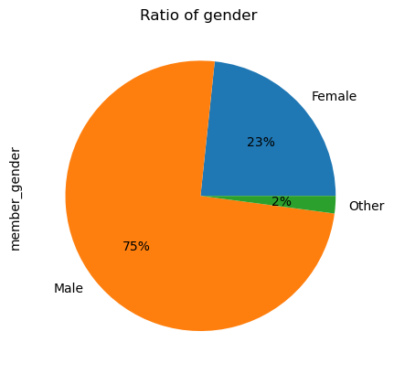

```python
# Lets get the ratio of gender
gender = df.groupby('member_gender')['member_gender'].count()
gender.plot(kind='pie', autopct='%1.0f%%')
plt.title('Ratio of gender ')
plt.show()
```

```
- Huge majority of individuals using our bike services are Male, follow by female and other
- Promotion is needed to incorporate more Females
```

```python
# Ratio of user type
```

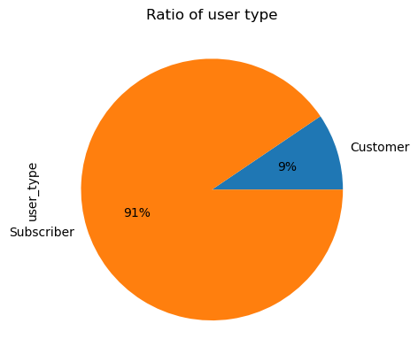

```python
user_ratio = df.groupby('user_type')['user_type'].count()
user_ratio.plot(kind = 'pie',autopct='%1.0f%%')
plt.title('Ratio of user type')
plt.show()
```

Our bike system is highly dominated by subscribers than customers for the month of Feburary

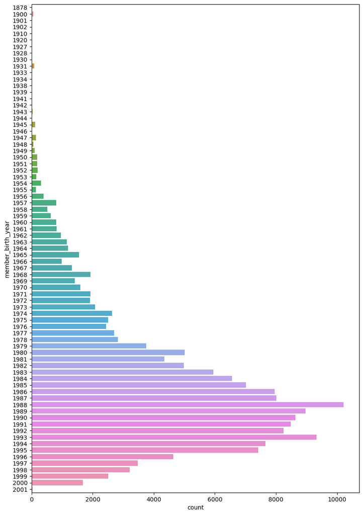

```python
# Lets look at the most popular birth year
plt.figure(figsize=(10,15))
sns.countplot(data=df, y='member_birth_year')
```

```python
# Lets look at the age distribution of our users
df['member_age'].describe()
```

```
count    174952.000000
mean         33.196865
std          10.118731
min          17.000000
25%          26.000000
50%          31.000000
75%          38.000000
max         140.000000
Name: member_age, dtype: float64
```

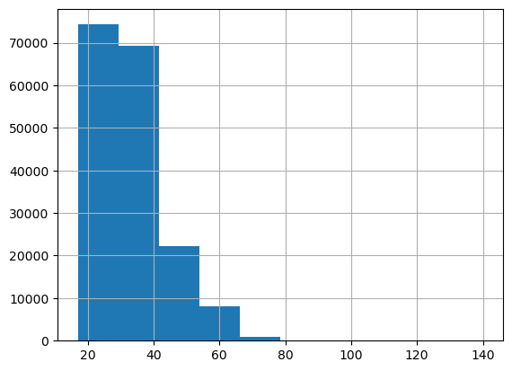

```python
df['member_age'].hist()
```

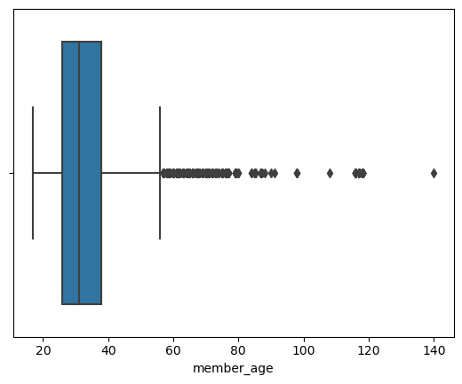

```python
sns.boxplot(data=df, x="member_age")
```

From the above analysis, the distribution of member age is skewd to the right which means majority of the users are young and few older people might be outliers. Lets check the age group to verify this

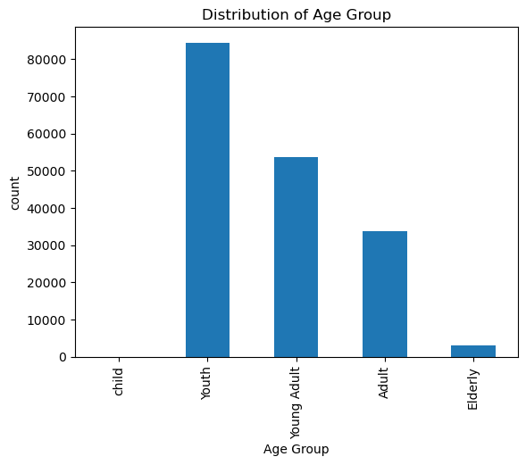

```python
age_group_count = df.groupby('age_group')['age_group'].count()
age_group_count.plot(kind='bar')
plt.title('Distribution of Age Group')
plt.xlabel('Age Group')
plt.ylabel('count')
plt.show()
```

our bike system is used mostly by Youth and Young Adult, they have more energy and are risk tolentant comapare to Elderly and we have no child below 16 years using our service

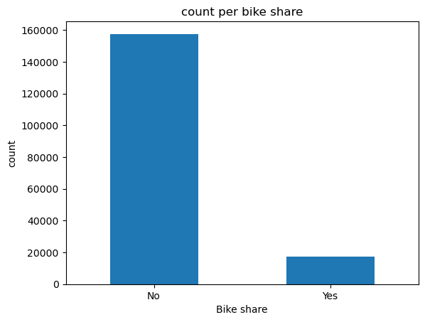

```python
# Lets check the number of bike share trips
age_group_count = df.groupby('bike_share_for_all_trip')['bike_share_for_all_trip'].count()
age_group_count.plot(kind='bar')
plt.title('count per bike share')
plt.xlabel('Bike share')
plt.xticks(rotation=0)
plt.ylabel('count')
plt.show()
```

Fewer bikes trips were shared, while a greater portion of bike trips where not shared

#### Bivariate Exploration

```
- Question 1: What potion of each gender subscribe but are not customer?
- Question 2: What the reationship between the age and travel time(duration)?
```

```python
customer = df[df['user_type'] == 'Customer']
subscriber = df[df['user_type'] == 'Subscriber']
```

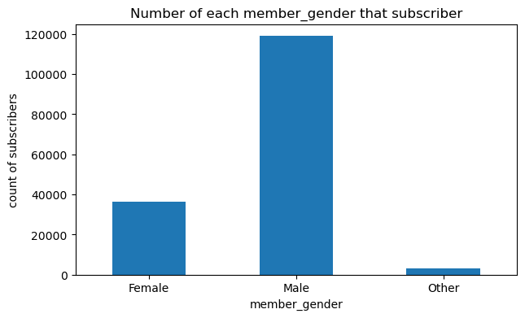

```python
def column_count(col):
    cust = customer.groupby(col)['user_type'].count()
    sub = subscriber.groupby(col)['user_type'].count()


    # Visualizing number of gender that are subscriber
    plt.figure(figsize=(7,4))
    sub.plot(kind = 'bar', label= "Subscriber")
    plt.ylabel('count of subscribers')
    plt.xticks(rotation=0)
    plt.title(f'Number of each {col} that subscriber')
    plt.show()


column_count('member_gender')
```

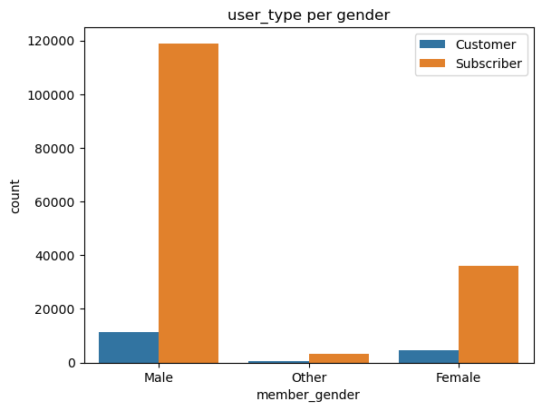

```python
# Lets check out the number user type found in each gender
sns.countplot(data= df, x="member_gender", hue="user_type")
plt.title('user_type per gender')
plt.legend(loc = 'upper right')
```

Vast majority of over 50% of each gender are subscribers compare to the few that are just customers

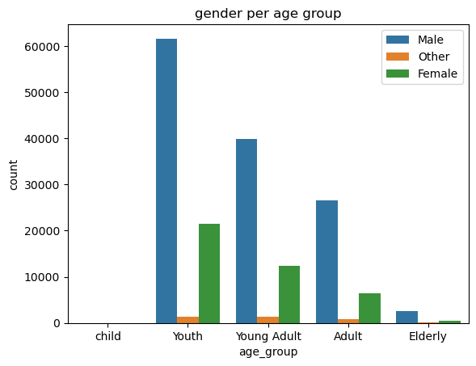

```python
# Lets check out the number user type found in each gender
sns.countplot(data= df, x="age_group", hue="member_gender")
plt.title('gender per age group')
plt.legend(loc = 'upper right');
```

From the previous ratio of gender analysis, we saw that our dataset have a huge percentage of male, follow by female and fewer others. Now checking the gender per age group, we expected to see similar trend which is confirmed above.

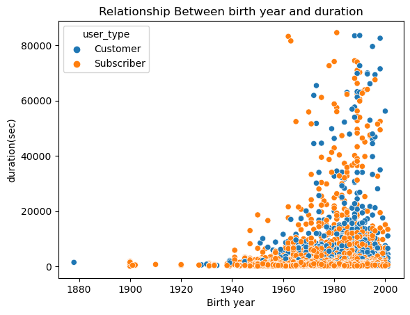

```python
sns.scatterplot(data=df, x='member_birth_year', y='duration_sec', hue='user_type')
plt.xlabel('Birth year')
plt.ylabel('duration(sec)')
plt.title('Relationship Between birth year and duration');
```

```python
# Lets check for the average travel time (duration)
avg_trip = df['duration_sec'].mean()
avg_trip
```

```
704.0027436096758
```

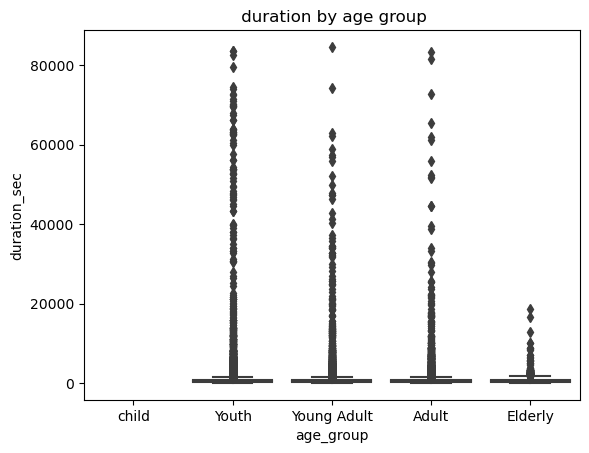

```python
# Lets plot a boxplot for user type per duration
sns.boxplot(data=df, x= 'age_group', y='duration_sec', )
plt.title(" duration by age group");
```

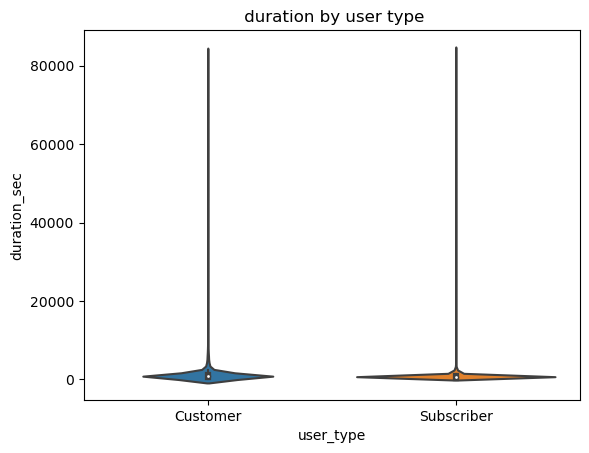

```python
# Lets plot a violinplot for user type per duration
sns.violinplot(data=df, x= 'user_type', y='duration_sec', )
plt.title(" duration by user type");
```

The average travel time is around 700 seconds and both customer and subscriber have similar distribution per duration second, this could be the reason we didn't identify a trend for user type in the previous scatterplot.

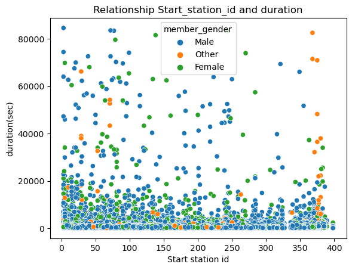

```python
# Lets look at the most popular start stations
sns.scatterplot(data=df, x='start_station_id', y='duration_sec', hue='member_gender')
plt.xlabel('Start station id')
plt.ylabel('duration(sec)')
plt.title('Relationship Start_station_id and duration');
```

### Conclusion

This analysis project has given us alot of insight into our dataset, and will help us find solution to some problems and improve our services to drive more users and increase revenue. Some insight we gather are:

[output not shown]

Please note, this is not a torough analysis and a lot more insight can be discover in the future to improver our services.